# Univariate Plots Section

```r
getwd()
```

```
## [1] "C:/Users/xiaoxiaojun/Desktop/projectTemplate"
```

```r
getwd()
```

```
## [1] "C:/Users/xiaoxiaojun/Desktop/projectTemplate"
```

```r
wq<- read.csv('wineQualityReds.csv')

names(wq)
```

```
##  [1] "X"                    "fixed.acidity"        "volatile.acidity"
##  [4] "citric.acid"          "residual.sugar"       "chlorides"
##  [7] "free.sulfur.dioxide"  "total.sulfur.dioxide" "density"
## [10] "pH"                   "sulphates"            "alcohol"
## [13] "quality"
```

```r
summary(wq)
```

```
##        X          fixed.acidity   volatile.acidity  citric.acid
##  Min.   :   1.0   Min.   : 4.60   Min.   :0.1200   Min.   :0.000
##  1st Qu.: 400.5   1st Qu.: 7.10   1st Qu.:0.3900   1st Qu.:0.090
##  Median : 800.0   Median : 7.90   Median :0.5200   Median :0.260
##  Mean   : 800.0   Mean   : 8.32   Mean   :0.5278   Mean   :0.271
##  3rd Qu.:1199.5   3rd Qu.: 9.20   3rd Qu.:0.6400   3rd Qu.:0.420
##  Max.   :1599.0   Max.   :15.90   Max.   :1.5800   Max.   :1.000
##  residual.sugar     chlorides       free.sulfur.dioxide
##  Min.   : 0.900   Min.   :0.01200   Min.   : 1.00
##  1st Qu.: 1.900   1st Qu.:0.07000   1st Qu.: 7.00
##  Median : 2.200   Median :0.07900   Median :14.00
##  Mean   : 2.539   Mean   :0.08747   Mean   :15.87
##  3rd Qu.: 2.600   3rd Qu.:0.09000   3rd Qu.:21.00
##  Max.   :15.500   Max.   :0.61100   Max.   :72.00
##  total.sulfur.dioxide    density             pH          sulphates
##  Min.   :  6.00       Min.   :0.9901   Min.   :2.740   Min.   :0.3300
##  1st Qu.: 22.00       1st Qu.:0.9956   1st Qu.:3.210   1st Qu.:0.5500
##  Median : 38.00       Median :0.9968   Median :3.310   Median :0.6200
##  Mean   : 46.47       Mean   :0.9967   Mean   :3.311   Mean   :0.6581
##  3rd Qu.: 62.00       3rd Qu.:0.9978   3rd Qu.:3.400   3rd Qu.:0.7300
##  Max.   :289.00       Max.   :1.0037   Max.   :4.010   Max.   :2.0000
##     alcohol         quality
##  Min.   : 8.40   Min.   :3.000
##  1st Qu.: 9.50   1st Qu.:5.000
##  Median :10.20   Median :6.000
##  Mean   :10.42   Mean   :5.636
##  3rd Qu.:11.10   3rd Qu.:6.000
##  Max.   :14.90   Max.   :8.000
```

### quality

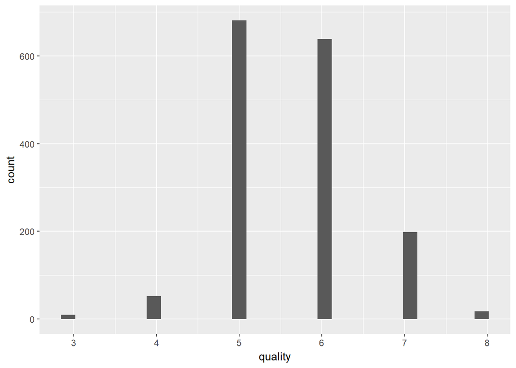

```r
ggplot(aes(x=quality),data=wq)+
  geom_histogram()
```

```r
summary(wq$quality)
```

```
##    Min. 1st Qu.  Median    Mean 3rd Qu.    Max.
##   3.000   5.000   6.000   5.636   6.000   8.000
```

红酒的品质主要集中在中等品质（5-6分），高品质（7-8分）和低品质（3-4分）都比较少。

```r
dim(subset(wq,quality==5|quality==6))/dim(wq)
```

```
## [1] 0.8248906 1.0000000
```

红酒质量quality=5或6的，占数据集总数的82.5%。

### density

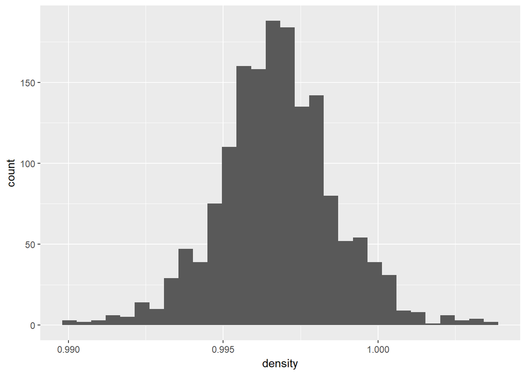

```r
qplot(x=density,data=wq)+
  geom_histogram()
```

```r
summary(wq$density)
```

```
##    Min. 1st Qu.  Median    Mean 3rd Qu.    Max.
##  0.9901  0.9956  0.9968  0.9967  0.9978  1.0037
```

分析得：红酒的密度与水很接近,酒精比水的密度略小，因此红酒的密度比水略小。数据呈正态分布。

### pH

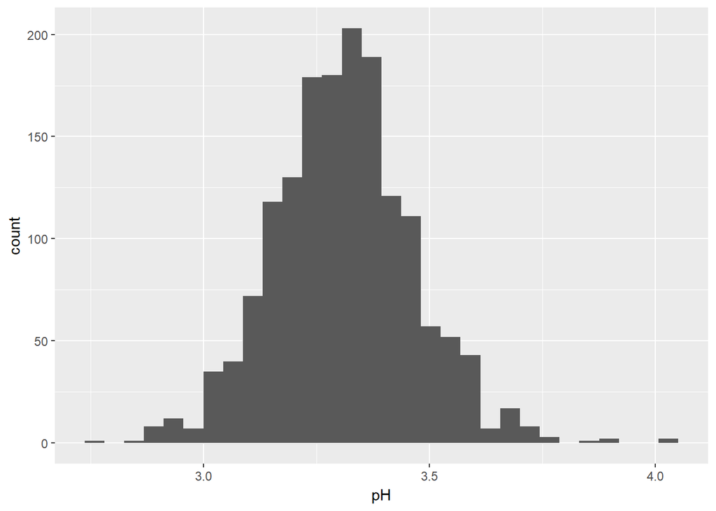

```r
qplot(x=pH,data=wq)+
  geom_histogram()
```

```r
summary(wq$pH)
```

```
##    Min. 1st Qu.  Median    Mean 3rd Qu.    Max.
##   2.740   3.210   3.310   3.311   3.400   4.010
```

红酒呈酸性，主要集中在3.0~3.7之间。呈正态分布。

### alcohol

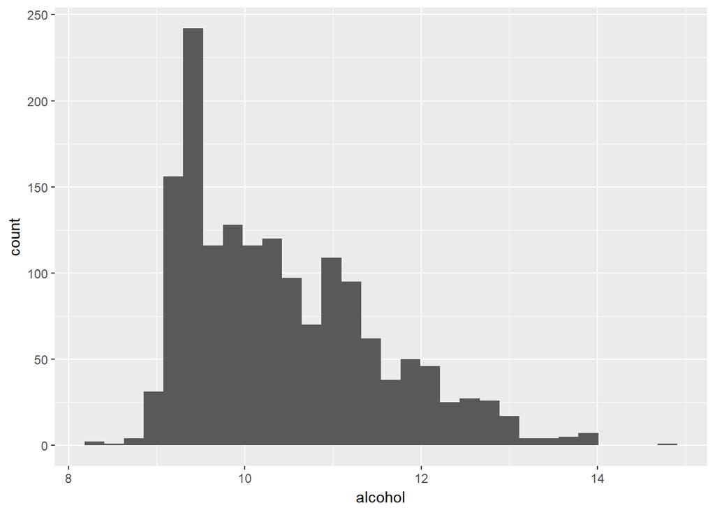

```r
ggplot(aes(x=alcohol),data=wq)+
  geom_histogram()
```

```r
summary(wq$alcohol)
```

```
##    Min. 1st Qu.  Median    Mean 3rd Qu.    Max.
##    8.40    9.50   10.20   10.42   11.10   14.90
```

酒精含量集中在8~15度，红酒为低度酒。呈右偏的分布。

### fixed.acidity

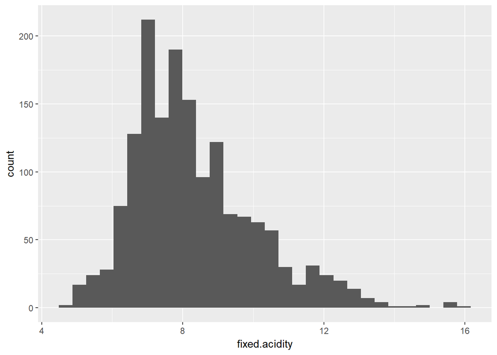

```r
qplot(x=fixed.acidity,data=wq)+
  geom_histogram()
```

```r
summary(wq$fixed.acidity)
```

```
##    Min. 1st Qu.  Median    Mean 3rd Qu.    Max.
##    4.60    7.10    7.90    8.32    9.20   15.90
```

固定酸度大致分布在6~10( g / dm^3)之间。稍许有些右偏分布，用scale_x_log10调整下。

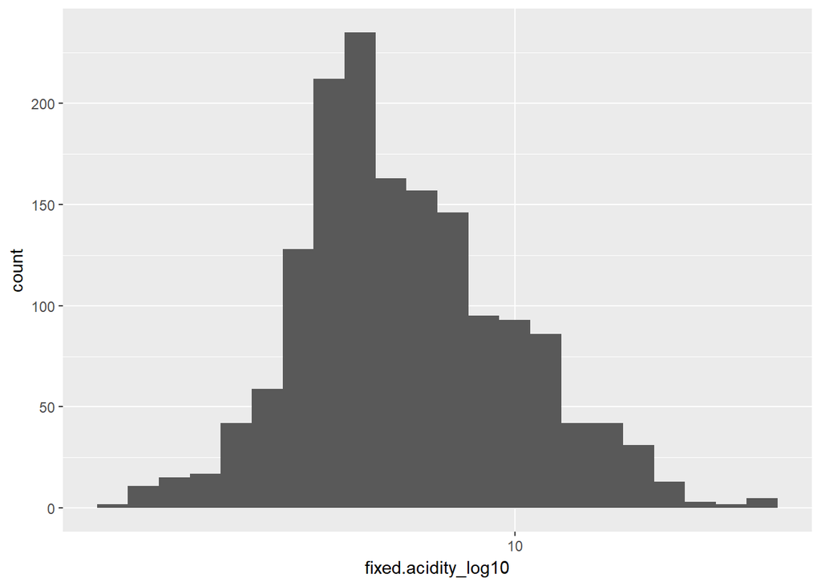

```r
ggplot(wq, aes(fixed.acidity)) +
  geom_histogram(binwidth = 0.025) +
  scale_x_log10() +
  xlab("fixed.acidity_log10")
```

转化为以log10的x轴，直方图近似正态分布。

### volatile.acidity

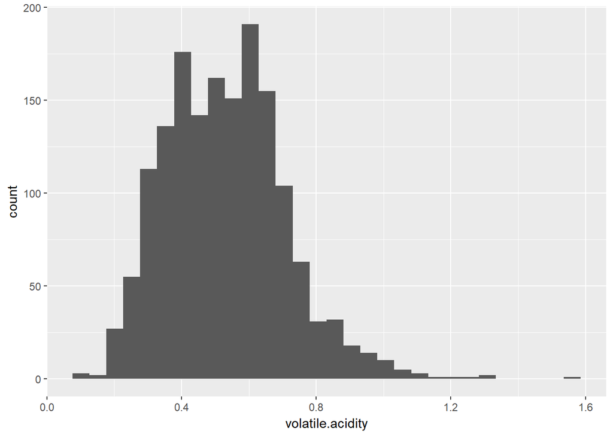

```r
qplot(x=volatile.acidity,data=wq)+
  geom_histogram()
```

```r
summary(wq$volatile.acidity)
```

```
##    Min. 1st Qu.  Median    Mean 3rd Qu.    Max.
##  0.1200  0.3900  0.5200  0.5278  0.6400  1.5800
```

挥发性酸度集中在0.3~0.9( g / dm^3)之间。有异常值和长尾分布。

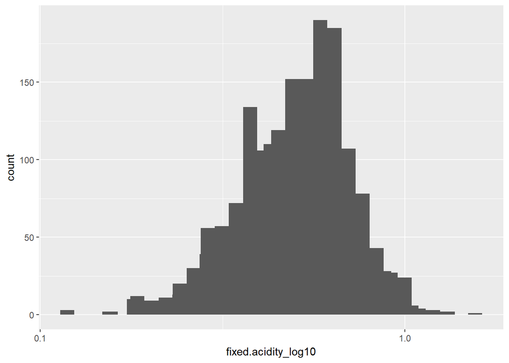

```r
qplot(x=volatile.acidity,data=wq)+
  geom_histogram(binwidth =0.025 )+
  scale_x_log10()+
  xlab("fixed.acidity_log10")
```

转化为以log10的x轴，直方图近似正态分布。

### critric.acid

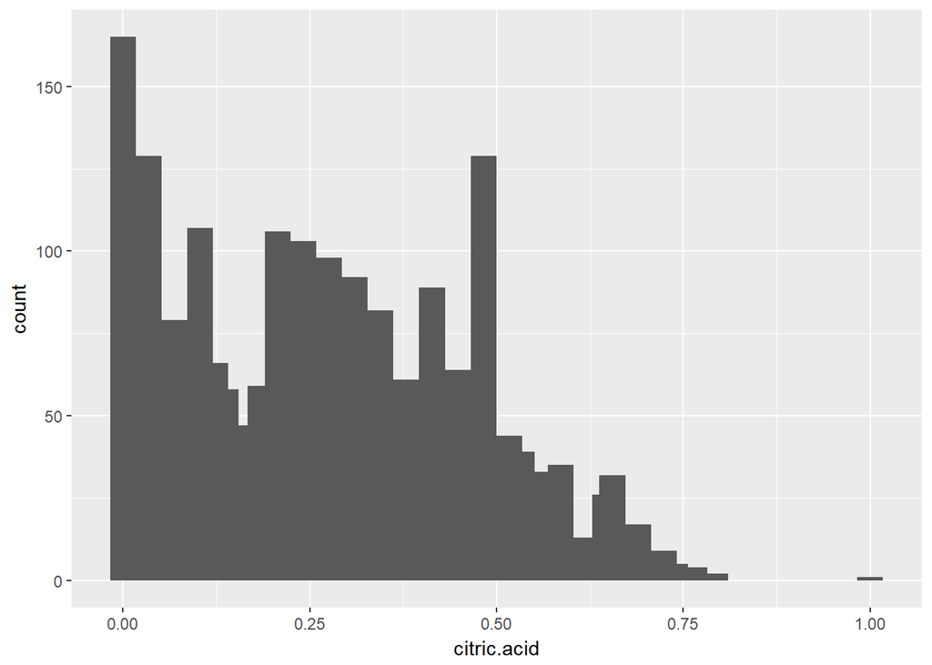

```r
qplot(x=citric.acid,data=wq)+
  geom_histogram(bins=40)
```

citric.acid 柠檬酸呈右偏分布。主要分布在0~0.7（g / dm^3）。

### residual.sugar

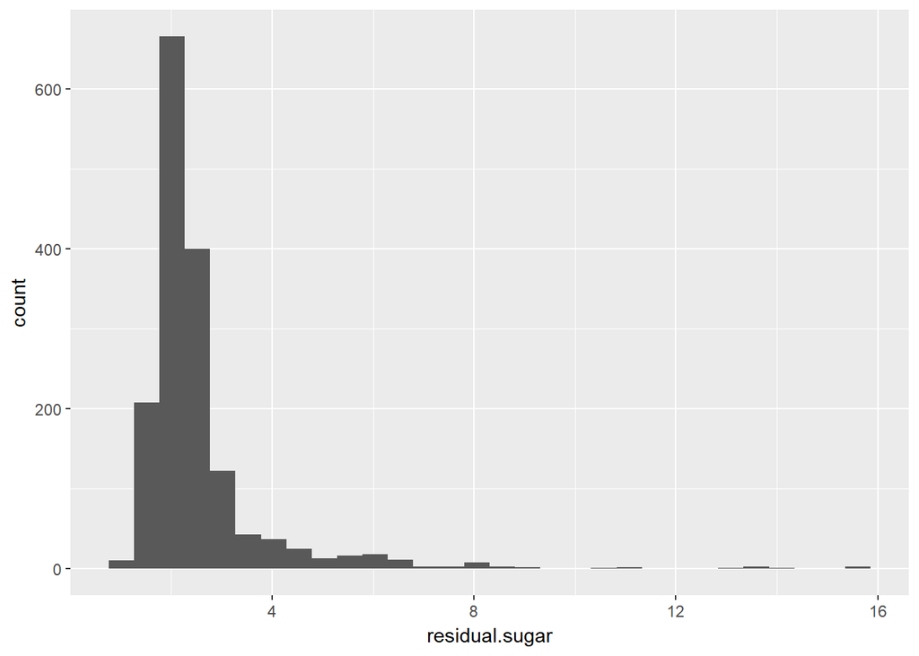

```r
qplot(x=residual.sugar,data=wq)+
  geom_histogram()
```

```r
summary(wq$residual.sugar)
```

```
##    Min. 1st Qu.  Median    Mean 3rd Qu.    Max.
##   0.900   1.900   2.200   2.539   2.600  15.500
```

残余糖集中在1~4( g / dm^3)之间。葡萄酒是低糖度的酒。直方图呈右偏分布，右偏分布考虑尝试transform。

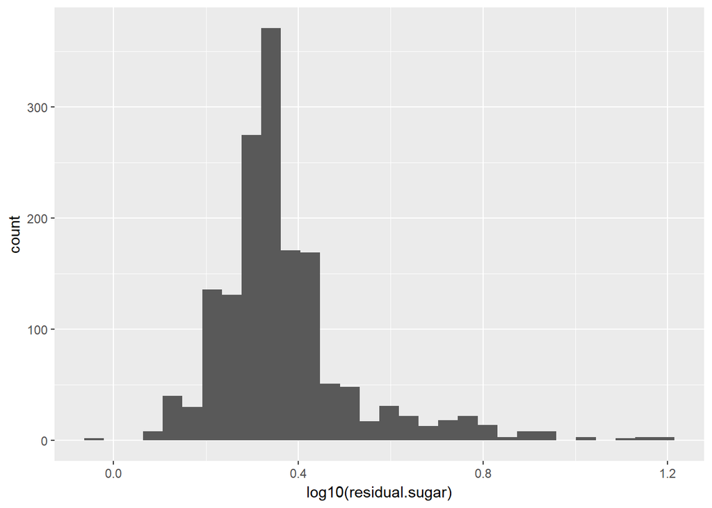

```r
qplot(x=log10(residual.sugar),data=wq)+
  geom_histogram(bins=30)
```

然后调整下x轴坐标

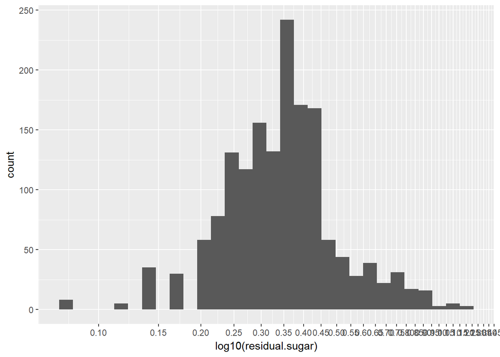

```r
qplot(x=log10(residual.sugar),data=wq)+
  geom_histogram(bins=30)+
  scale_x_log10(breaks=seq(0,3,0.05))
```

调整后，residual.sugar近似正态分布。

### chlorides

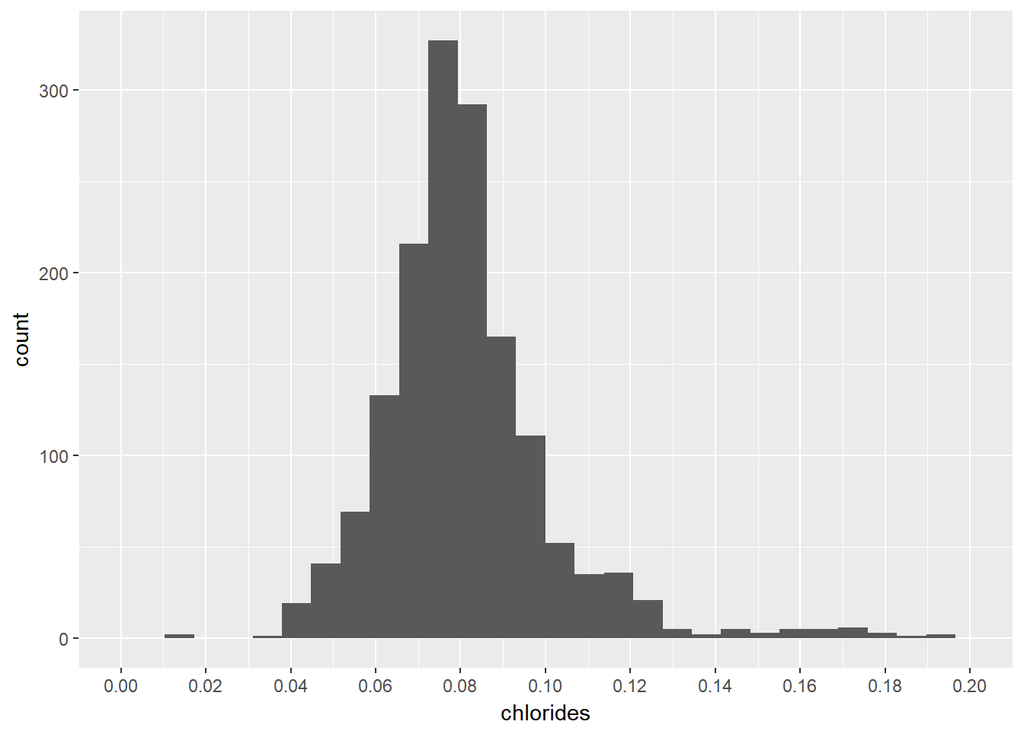

```r
qplot(x= chlorides,data=wq)+
  geom_histogram()+
  scale_x_continuous(lim=c(0,0.2),breaks =seq(0,0.2,0.02) )
```

```r
summary(wq$chlorides)
```

```
##    Min. 1st Qu.  Median    Mean 3rd Qu.    Max.
## 0.01200 0.07000 0.07900 0.08747 0.09000 0.61100
```

氯化物集中0.04~0.12(g/dm^3)，chlorids数据有一些异常值，我们需要排除它们。

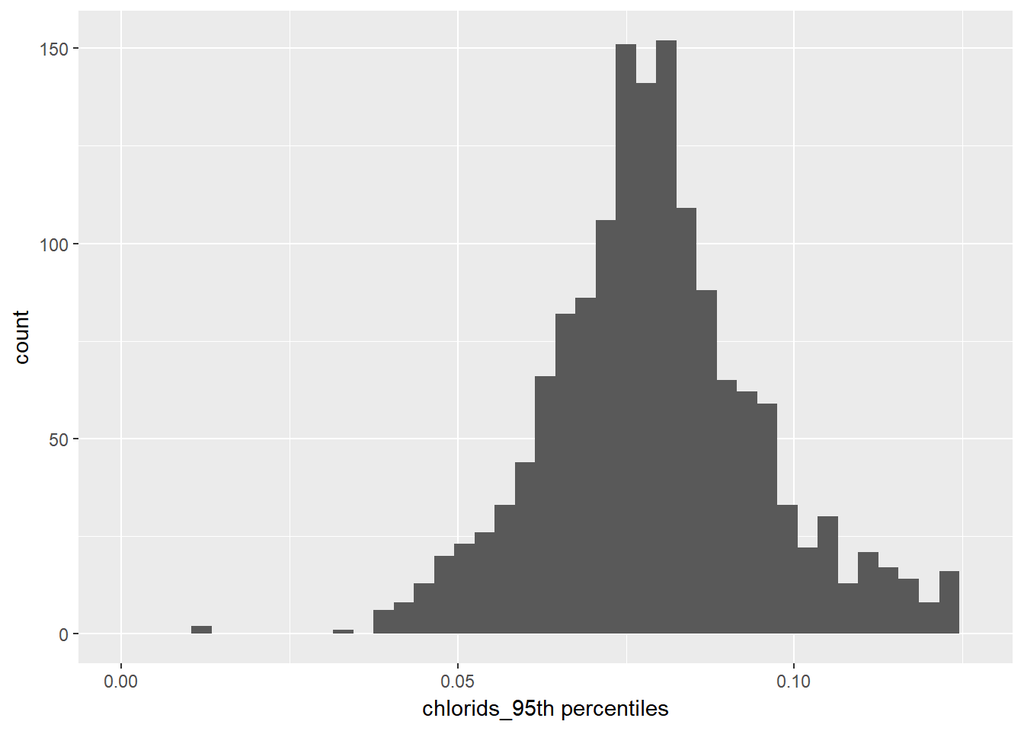

```r
ggplot(wq,aes(chlorides))+
  geom_histogram(binwidth=0.003)+
  scale_x_continuous(lim=c(0,quantile(wq$chlorides,0.95)))+
  xlab("chlorids_95th percentiles")
```

排除异常值，chlorides数据更接近于正态分布。

### free.sulfur.dioxide

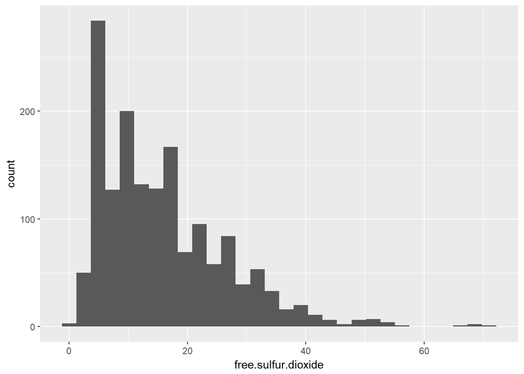

```r
qplot(x=free.sulfur.dioxide,data=wq)+
  geom_histogram()
```

```r
summary(wq$free.sulfur.dioxide)
```

```
##    Min. 1st Qu.  Median    Mean 3rd Qu.    Max.
##    1.00    7.00   14.00   15.87   21.00   72.00
```

### total.sulfur.dioxide

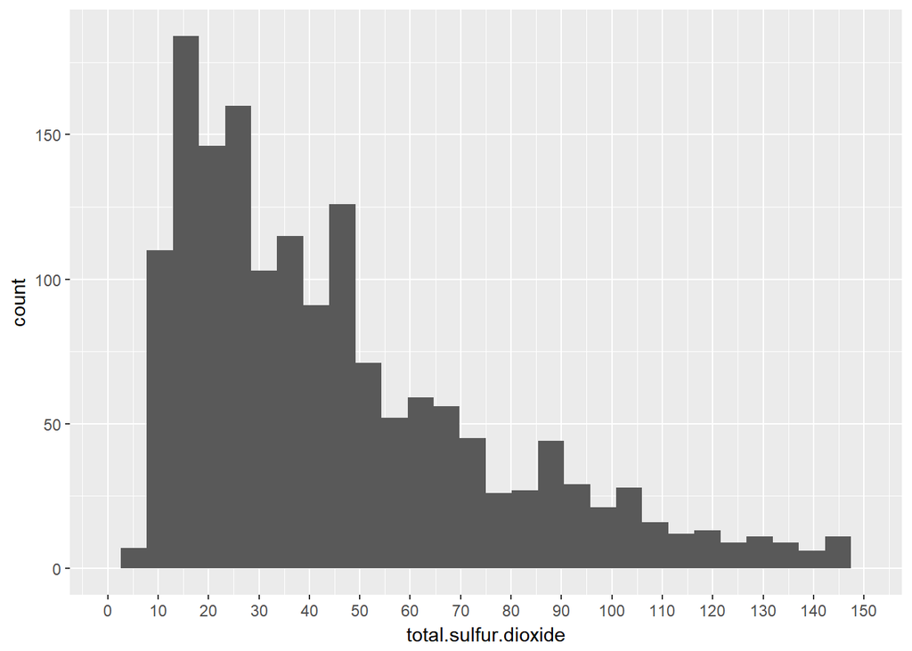

```r
qplot(x=total.sulfur.dioxide,data=wq)+
  geom_histogram()+
  scale_x_continuous(lim=c(0,150),breaks =seq(0,150,10) )
```

```r
summary(wq$total.sulfur.dioxide)
```

```
##    Min. 1st Qu.  Median    Mean 3rd Qu.    Max.
##    6.00   22.00   38.00   46.47   62.00  289.00
```

总的二氧化硫分布在5~50(mg/dm^3)之间，呈右偏分布。

### sulohates

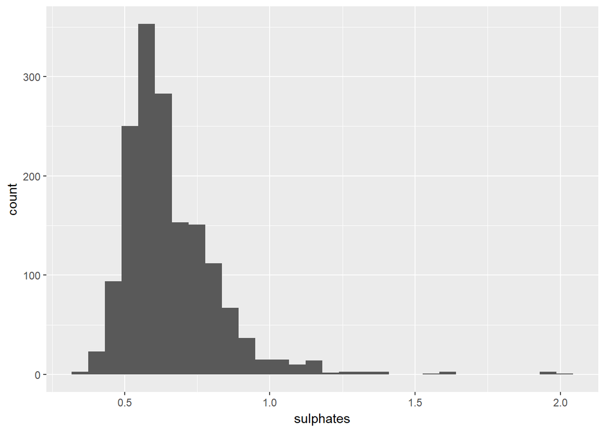

```r
qplot(x=sulphates,data=wq)+
  geom_histogram()
```

```r
summary(wq$sulphates)
```

```
##    Min. 1st Qu.  Median    Mean 3rd Qu.    Max.
##  0.3300  0.5500  0.6200  0.6581  0.7300  2.0000
```

红酒中硫酸盐添加剂只要分布在0.4~0.8(g/dm^3)之间，成右偏分布。

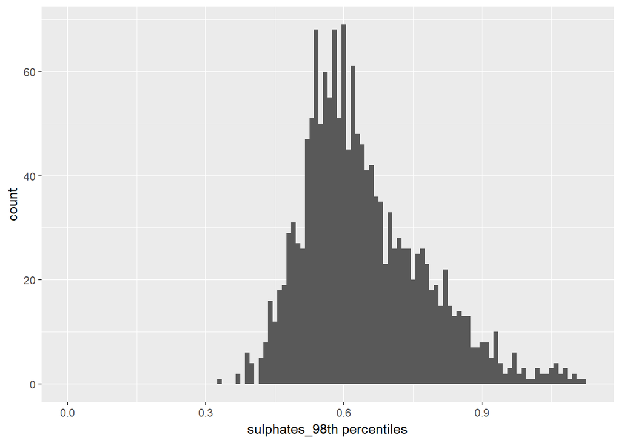

```r
ggplot(wq, aes(sulphates)) +
  geom_histogram(binwidth = 0.01) +
  scale_x_continuous(lim=c(0, quantile(wq$sulphates, 0.98))) +
  xlab("sulphates_98th percentiles")
```

排除异常值后，suphates数据近似正态分布。

# Univariate Analysis

本项目使用红酒品质数据集。目的是探究哪些物理化学性质影响了红酒质量。使用工具为R。

### What is the structure of your dataset?

```
数据集中有1599个观察值，13个变量，有一个唯一标识符x和11个关于酒的化学成分的变量（固定酸度，挥发性酸度，柠檬酸，残余糖，氯化物，游离二氧化硫，总二氧化硫，密度，PH值，硫酸盐，酒精）和1个质量评分变量。至少3位专家对每种酒的质量进行了评分，分数在0（非常差）到10（非常好）之间。
```

属性描述：

1-固定酸度: 大多数酸涉及葡萄酒或固定或非挥发性 (不容易挥发)

2-挥发性酸度: 葡萄酒中乙酸的含量过高会导致不愉快的醋味

3-柠檬酸: 少量, 柠檬酸可以增加葡萄酒的 ‘新鲜’ 和风味

4-残余糖: 发酵停止后剩余的糖量, 很少发现有少于1克/升的葡萄酒, 酒的含量大于45克/升被认为是甜的。

5-氯化物: 酒的盐量

6-自由二氧化硫: SO2 的自由形式存在于分子 SO2 (作为溶解气体) 和亚硫酸氢离子之间的平衡;它可以防止微生物的生长和葡萄酒的氧化。

7-总二氧化硫: S02 的自由和束缚的形式的数量;在低浓度, SO2 大多是无法察觉的酒, 但在自由 SO2 浓度超过 50 ppm, SO2 变得明显的鼻子和葡萄酒的味道

8-密度: 水的密度接近水, 取决于酒精和糖含量的百分比

9-pH: 描述如何酸或基本的葡萄酒是从 0 (非常酸性) 到 14 (非常基本) 的规模;大多数葡萄酒的 pH 值在3-4 之间

10-硫酸盐: 一种能促进二氧化硫气体 (S02) 含量的葡萄酒添加剂, 其作用是抗菌和抗氧化剂。

11-酒精: 酒的酒精含量的百分比

输出变量 (基于感官数据): 12-质量 (比分在0和10之间)

### What is/are the main feature(s) of interest in your dataset?

quality是主要特征。

### What other features in the dataset do you think will help support your investigation into your feature(s) of interest?

volatitle.acidity含挥发性酸,citric.acid柠檬酸,residual.sugar残余糖，pH,sulphates硫酸盐,alcohol酒精度可能会红酒质量有影响。

### Did you create any new variables from existing variables in the dataset?

没有，使用原始变量数据。

### Of the features you investigated, were there any unusual distributions? Did you perform any operations on the data to tidy, adjust, or change the form of the data? If so, why did you do this?

有些变量的直方图呈偏态分布，长尾部分较长。我对其进行log10的x轴转换，使其转换后，近似正态分布。

# Bivariate Plots Section

```r
corr <- NULL

for (i in names(wq)){
  corr[i] <- cor.test(as.numeric(wq[,i]),
                      as.numeric(wq$quality))$estimate
  }

corr
```

```
##                    X        fixed.acidity     volatile.acidity
##           0.06645261           0.12405165          -0.39055778
##          citric.acid       residual.sugar            chlorides
##           0.22637251           0.01373164          -0.12890656
##  free.sulfur.dioxide total.sulfur.dioxide              density
##          -0.05065606          -0.18510029          -0.17491923
##                   pH            sulphates              alcohol
##          -0.05773139           0.25139708           0.47616632
##              quality
##           1.00000000
```

相关性。与葡萄酒质量相关性高的有： alcohol：47.6% sulphates：25.1% citric.acid:22.6% volatile.acidity:-39.0% total.sulfur.dioxide:-18.5%

### alcohol & quality

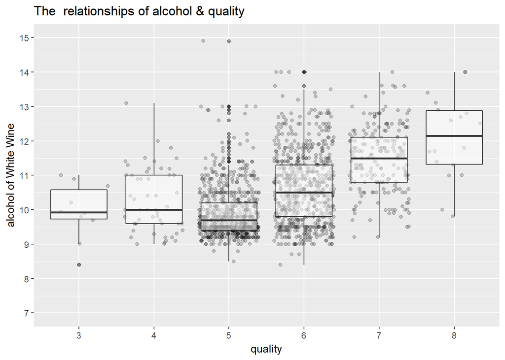

```r
ggplot(aes(x=factor(quality),y=alcohol),data=wq)+
  geom_jitter(alpha=1/5)+
  geom_boxplot(alpha=1/2)+
  scale_y_continuous(limits=c(7,15),breaks=seq(7,15,1))+
  ylab("alcohol of White Wine") +
  xlab("quality") +
  ggtitle("The  relationships of alcohol & quality ")
```

```r
by(wq$alcohol,wq$quality,summary)
```

```
## wq$quality: 3
##    Min. 1st Qu.  Median    Mean 3rd Qu.    Max.
##   8.400   9.725   9.925   9.955  10.575  11.000
## --------------------------------------------------------
## wq$quality: 4
##    Min. 1st Qu.  Median    Mean 3rd Qu.    Max.
##    9.00    9.60   10.00   10.27   11.00   13.10
## --------------------------------------------------------
## wq$quality: 5
##    Min. 1st Qu.  Median    Mean 3rd Qu.    Max.
##     8.5     9.4     9.7     9.9    10.2    14.9
## --------------------------------------------------------
## wq$quality: 6
##    Min. 1st Qu.  Median    Mean 3rd Qu.    Max.
##    8.40    9.80   10.50   10.63   11.30   14.00
## --------------------------------------------------------
## wq$quality: 7
##    Min. 1st Qu.  Median    Mean 3rd Qu.    Max.
##    9.20   10.80   11.50   11.47   12.10   14.00
## --------------------------------------------------------
## wq$quality: 8
##    Min. 1st Qu.  Median    Mean 3rd Qu.    Max.
##    9.80   11.32   12.15   12.09   12.88   14.00
```

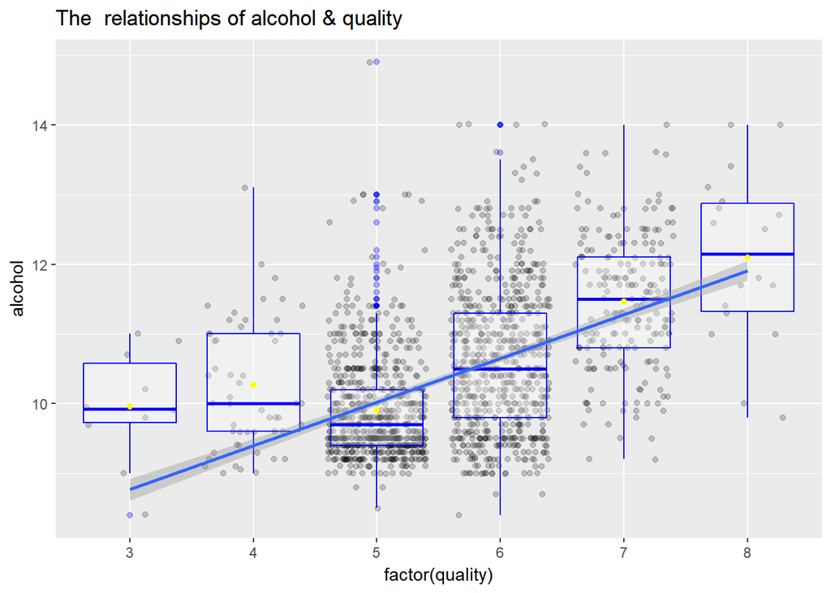

```r
ggplot(wq,aes(factor(quality),alcohol))+
  geom_jitter(alpha=0.2)+
  geom_boxplot(alpha=0.3,color='blue')+
  stat_summary(fun.y ="mean",
               geom="point",
               color="yellow")+
  geom_smooth(method='lm',aes(group=1))+
  ggtitle("The  relationships of alcohol & quality ")
```

一般来说，红酒的质量越好，对应的酒精浓度越高。